# PROSPER LOAN DATA ANALYSIS

## By Emily Hazelton

This report explores loan data provided by the online lender Prosper (a tidy dataset that Udacity prepared for student projects). The data spans from November, 2005 to March, 2014. Any column headers listed as “current” was current as of March 11, 2014, when the dataset was last pulled.

# Univariate Plots Section

There are 113,937 observations in the full dataset with 81 variables. I have picked 12 variables for this exploration, as detailed below. I’ve also shown a sample of the first 6 rows for each variable.

```
## [1] 113937     12
```

```
##  [1] "loan_amount"                "loan_term_months"
##  [3] "loan_status_current"        "employment_status"
##  [5] "employment_duration_months" "credit_score_lower"
##  [7] "credit_score_upper"         "debt_income_ratio"
##  [9] "stated_income_monthly"      "principal_paid"
## [11] "interest_and_fees_paid"     "estimated_return"
```

```
##   loan_amount loan_term_months loan_status_current employment_status
## 1        9425               36           Completed     Self-employed
## 2       10000               36             Current          Employed
## 3        3001               36           Completed     Not available
## 4       10000               36             Current          Employed
## 5       15000               36             Current          Employed
## 6       15000               60             Current          Employed
##   employment_duration_months credit_score_lower credit_score_upper
## 1                          2                640                659
## 2                         44                680                699
## 3                         NA                480                499
## 4                        113                800                819
## 5                         44                680                699
## 6                         82                740                759
##   debt_income_ratio stated_income_monthly principal_paid
## 1              0.17              3083.333        9425.00
## 2              0.18              6125.000           0.00
## 3              0.06              2083.333        3001.00
## 4              0.15              2875.000        4091.09
## 5              0.26              9583.333        1563.22
## 6              0.36              8333.333         351.89
##   interest_and_fees_paid estimated_return
## 1                1971.14               NA
## 2                   0.00          0.05470
## 3                1185.63               NA
## 4                1052.11          0.06000
## 5                1256.63          0.09066
## 6                 327.45          0.07077
```

Questions:

- What are the most popular categories for the loan status?

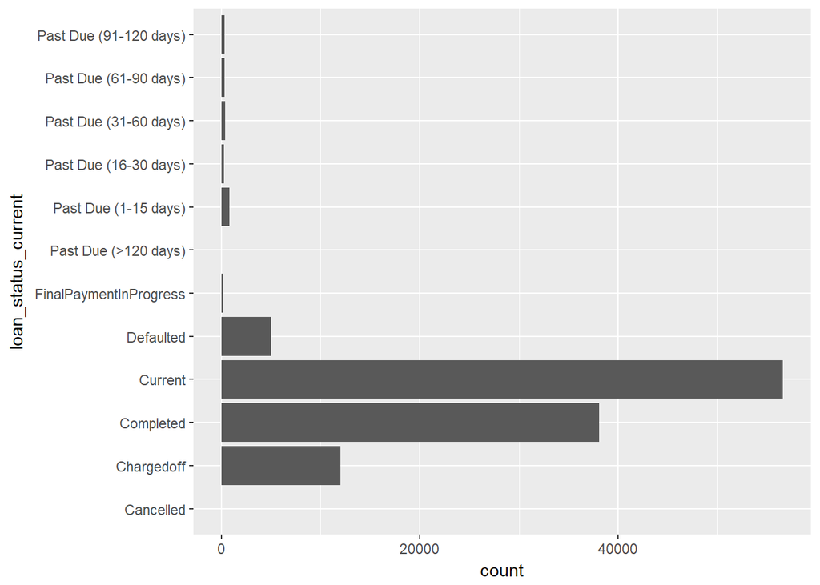

It looks like the most commonly occurring loan statuses are current, completed, and charged off.

Questions:

- What proportion of loans are charged off?
- What factors predict that the borrower will go into loan delinquency?
- What is the distribution of loan amounts?

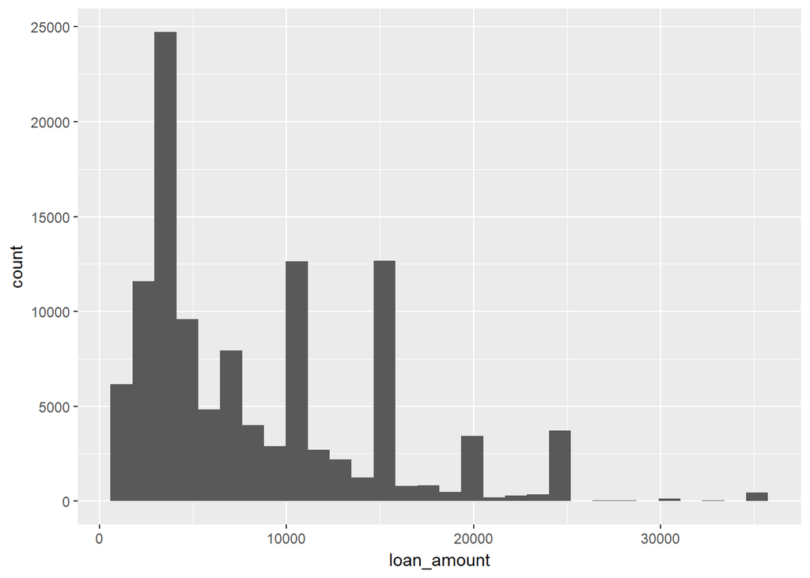

The default bin sizes here for loan amount makes it hard to see anything meaningful.

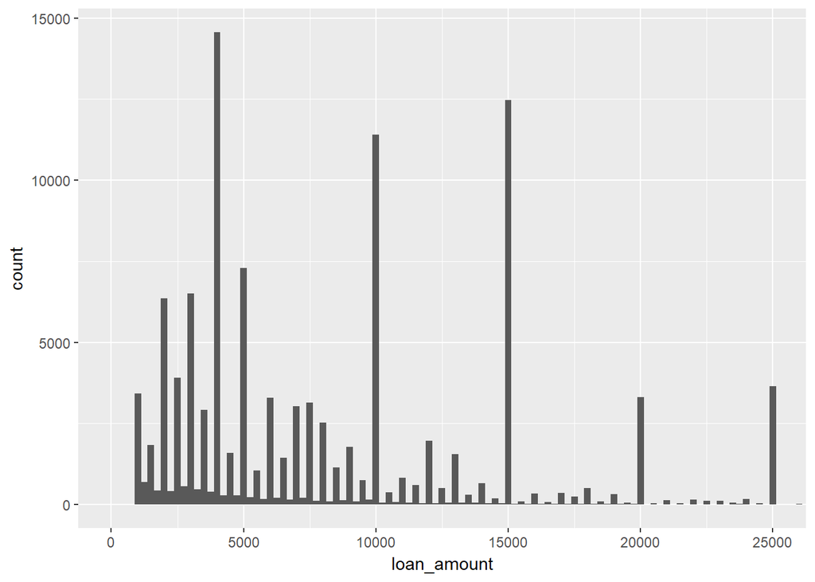

Unsurprisingly, loan amounts cluster around the 500 or 1,000 marks.

Most frequent loan amounts:

- $4,000
- $15,000
- $10,000
- $5,000

Question:

- How long do loan terms last?

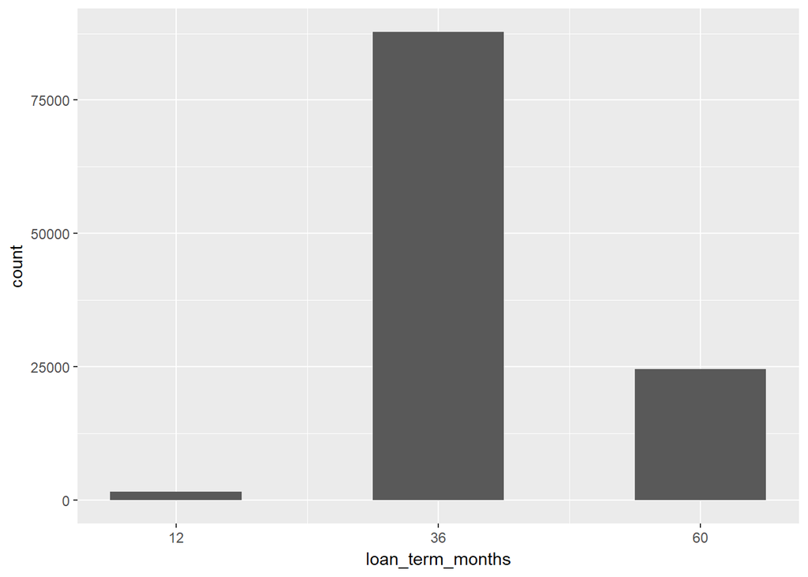

The loan terms in this data set fall into three bins: 12, 36, or 60 months, with 36 months being the most common. Since there are only 3 discrete values, I am going to change the vector type from integer to a factor, so I can graph it categorically in the bivariate section. I would also find the length-of-loan variable easier to interpret as 1, 3, or 5 years.

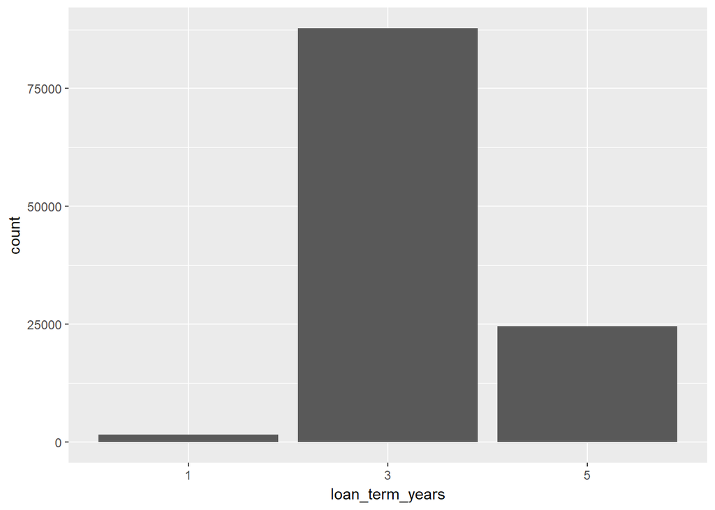

Questions:

- What is the average credit score for borrowers? I want to create an average from credit_score_lower and credit_score_uppers so that I have one variable to use for analysis.

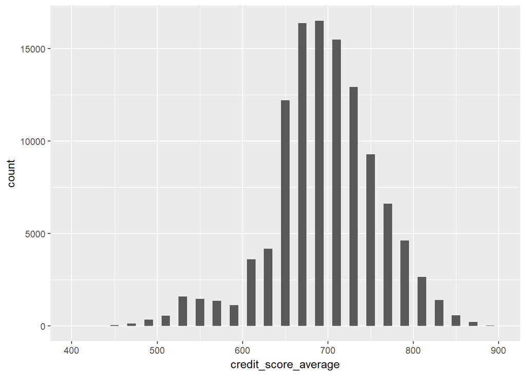

It looks like borrowers’ credit scores are normally distributed, with the peak in the 685-695 bin.

Questions:

- Why are there gaps in this continusous data set? Are credit score algorithms defined in such a way that every-other band of 10 digits is not a score where consumers can rank? NOTE: I made graphs of both credit_score_lower and credit_score_upper, and the same banding occurs. I removed them from this report for the sake of brevity, but the effect is not coming from the fact that I averaged these two variables.
- How much do borrowers make? NOTE: this variable is self reported, not verified by Prosper.

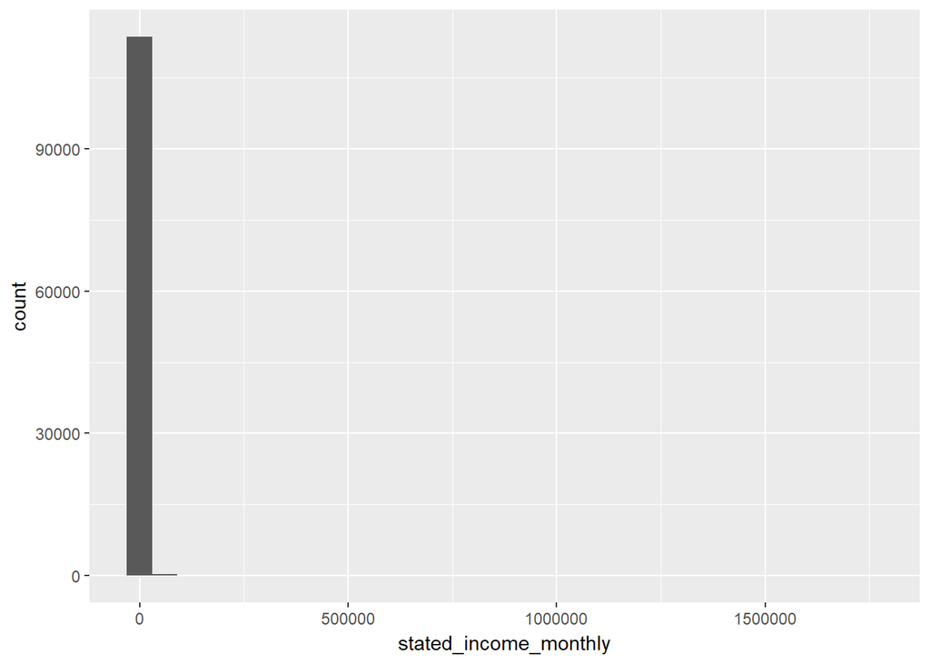

There are definitely some extreme outliers in here that are making the bins very unhelpful.

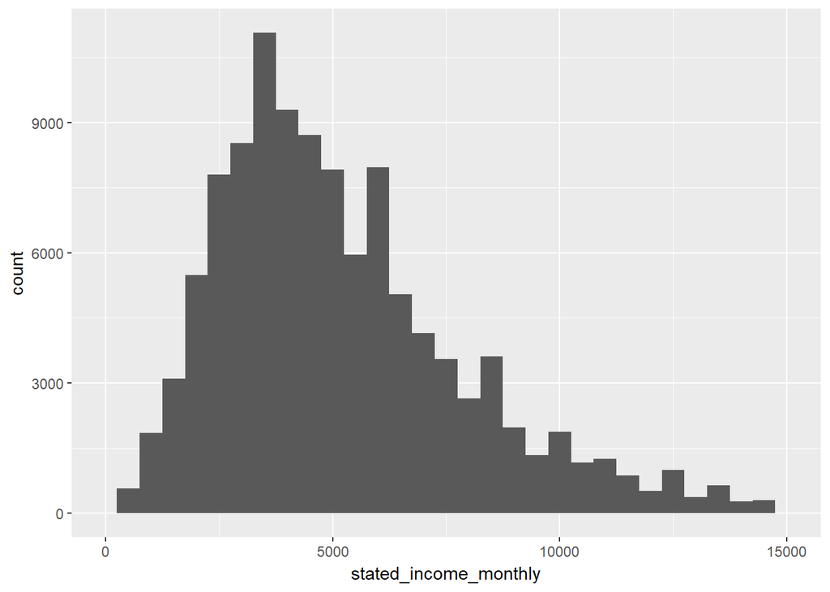

Monthly income appears to be normally distributed around a peak of about $3,000, with a long tail out into higher values. Since I’m used to interpreting income on an annual scale, I am going to create a new value here named stated_annual_income.

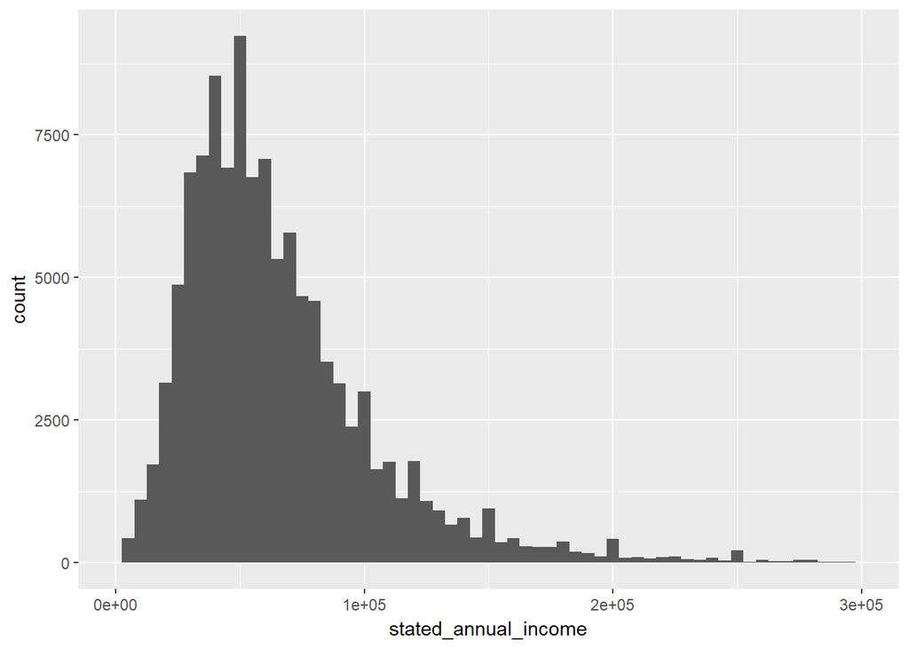

The normal distribution of income centers around the $30,000 to $50,000 range.

Question:

- What are borrowers’ employment statuses?

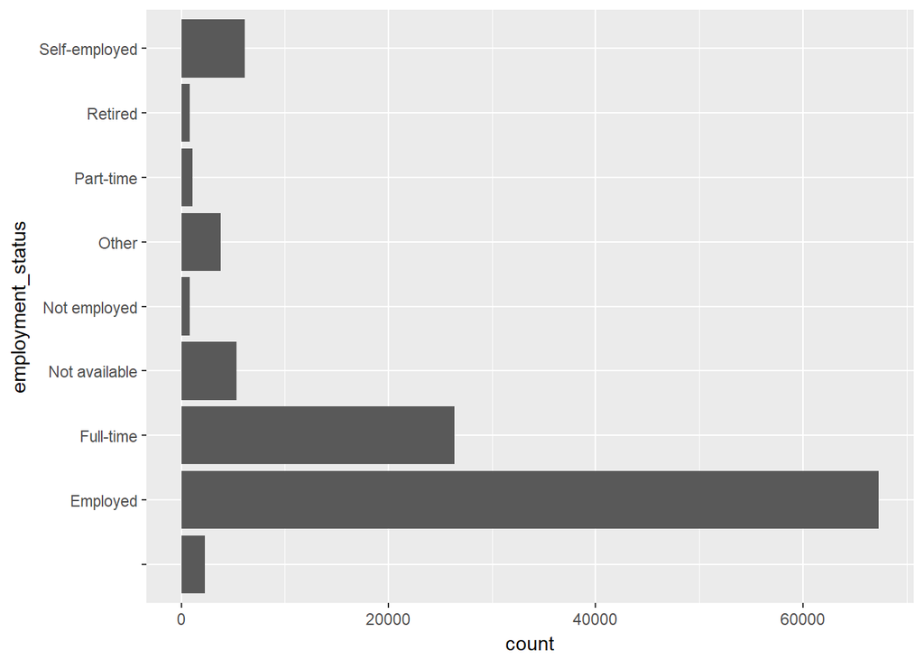

Question:

- How long have borrowers been employed?

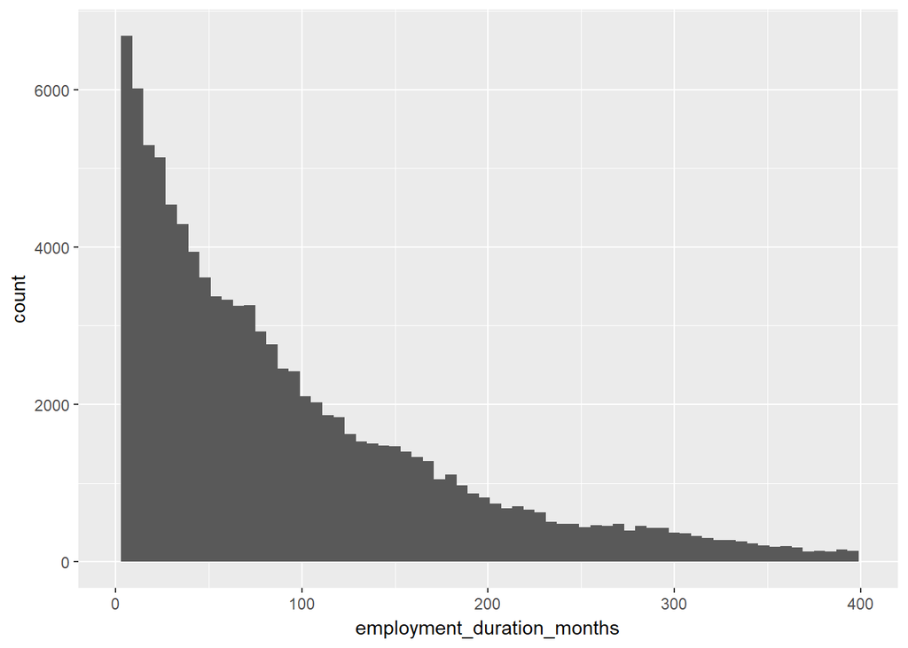

The above bins are 6-month time frames. I find this data difficult to interpret. I am going to convert it to yearly numbers.

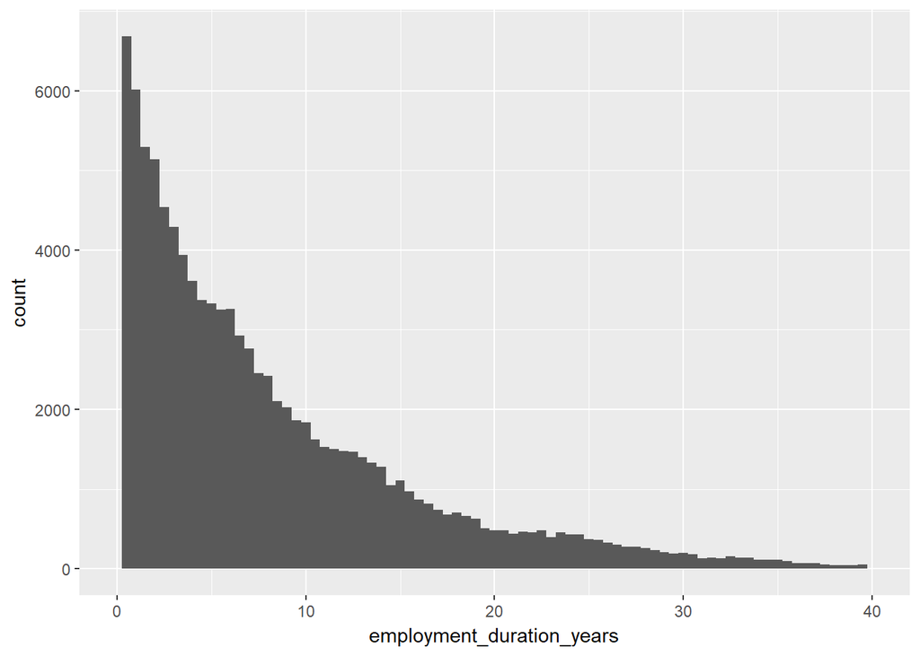

The most common bin is the .25-.75 years of employment, with the count of years employed steadily falling. Each bin above represents .5 years or 6 months.

Questions:

- How much does Prosper make from its lending?

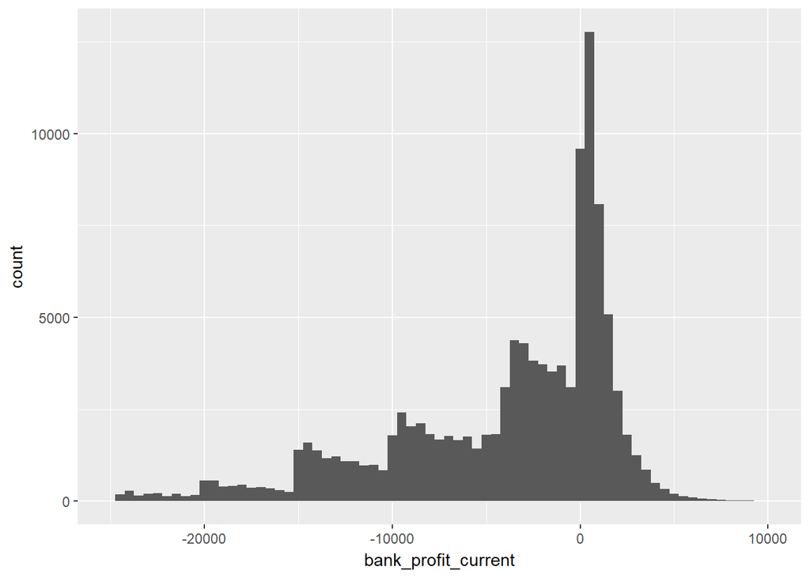

I created a new variable called bank_profit_current. The formula is principal paid plus interest and fees paid minus the original loan amount.

Questions:

*What are the unique loan_status values in the dataset?* How would this graph look for loans that are already closed?

```
##  [1] Completed              Current                Past Due (1-15 days)
##  [4] Defaulted              Chargedoff             Past Due (16-30 days)
##  [7] Cancelled              Past Due (61-90 days)  Past Due (31-60 days)
## [10] Past Due (91-120 days) FinalPaymentInProgress Past Due (>120 days)
## 12 Levels: Cancelled Chargedoff Completed Current ... Past Due (91-120 days)
```

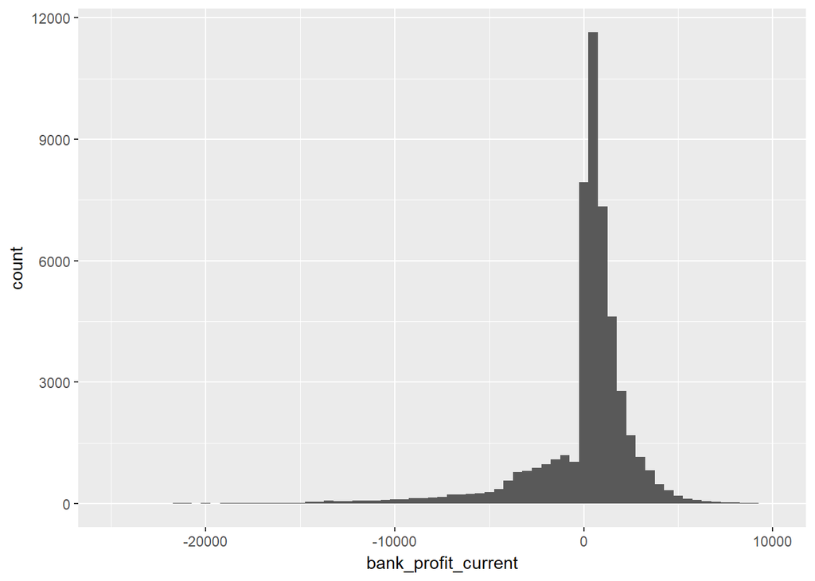

The above graph shows bank_profit_current for only Completed or Chargedoff loans. It looks like closed loans are more scewed to positive profit for the bank than all loans (open and closed). This makes sense.

Questions:

- What is the average profit per closed loan?

Mean bank profit on closed loans:

```
## [1] 21.1151
```

Average profit of $21.12 seems low to me.

Questions:

- How does actual profit compare to the estimated profit caculated by Prosper when they funded the loan?
- How much data do I have in the closed_loans dataset? Could I use this dataset for the rest of my analysis and have enough observations to draw conclusions that could help predict future performance of loans?

```
## [1] 50066    17
```

Yes, over 50,000 observaions seems sufficient to reasonably trust any conclusions drawn from this dataset. From here forward, I will be looking at this more specific dataset, named closed_loans in the R environment.

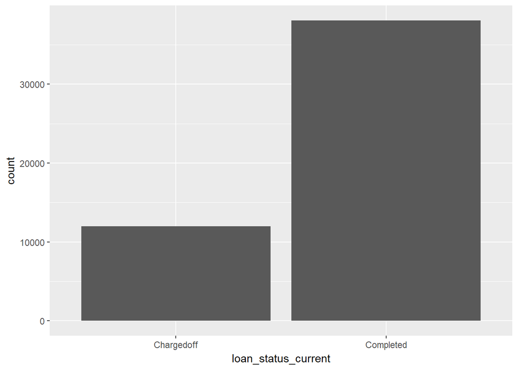

The above graph visually shows the counts of Chargedoff vs Completed loans. Completed loans are loans where the borrower completely paid off the original loan amount. 24.0 percent of closed loans are in the Chargedoff category.

Questions: * How many 1, 3, and 5 year loans fall within the closed status? * What is the spread of loan amounts within closed_loans?

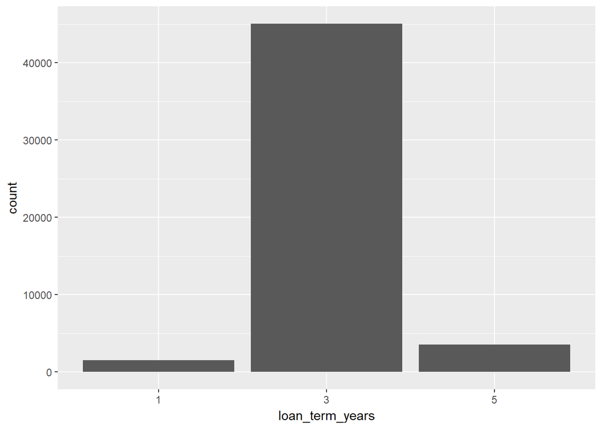

Three-year loans are still the most common. In relation to the 3-year loans, there are proportionally more 1-year loans and less 5-year loans as compared to the full Prosper loan dataset.

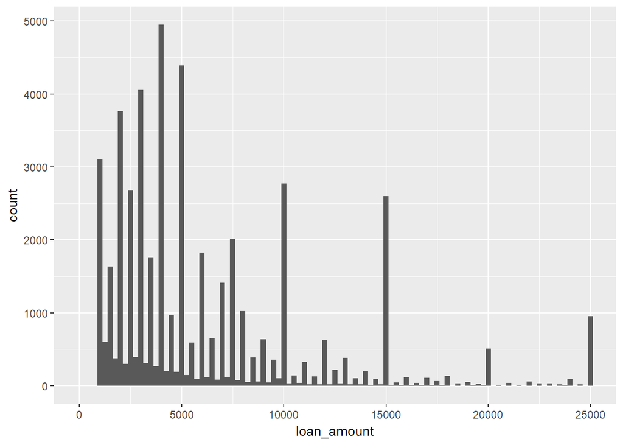

The spread for closed loans leans more towards smaller loans than the full Prosper set. Perhaps consumers were asking for smaller loans historically, or perhaps Prosper was more conservative in how much funding they would award to consumers as they refined their profit predictions – I don’t have a way to find the answer to that question with the dataset that I have.

Most popular loans:

- $4,000
- $5,000
- $3,000
- $2,000

With these smaller loan sizes, this smaller profit makes more sense. This data was also collected over the span of the recession, so interest rates would have been very low during that time. That also helps explain the low ROI per loan.

Question:

- What type of return does the bank expect to make on its lending?

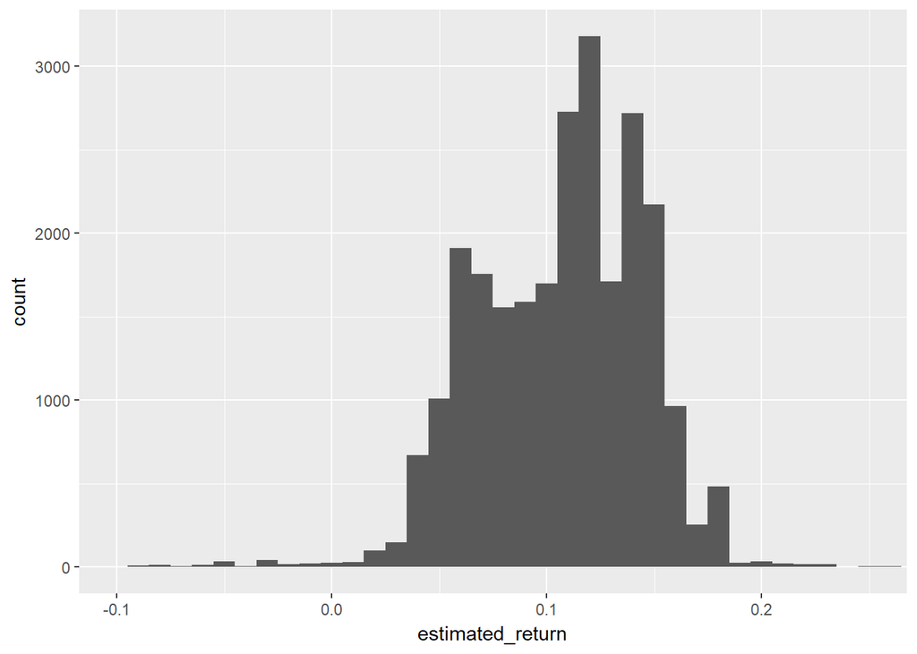

This graph shows what the bank estimated the return to be when they funded the loan. It looks like there is a spread between 0.025 and 0.2 (or 2.5 to 20 percent of return on investment).

Questions:

- What does actual return look like?

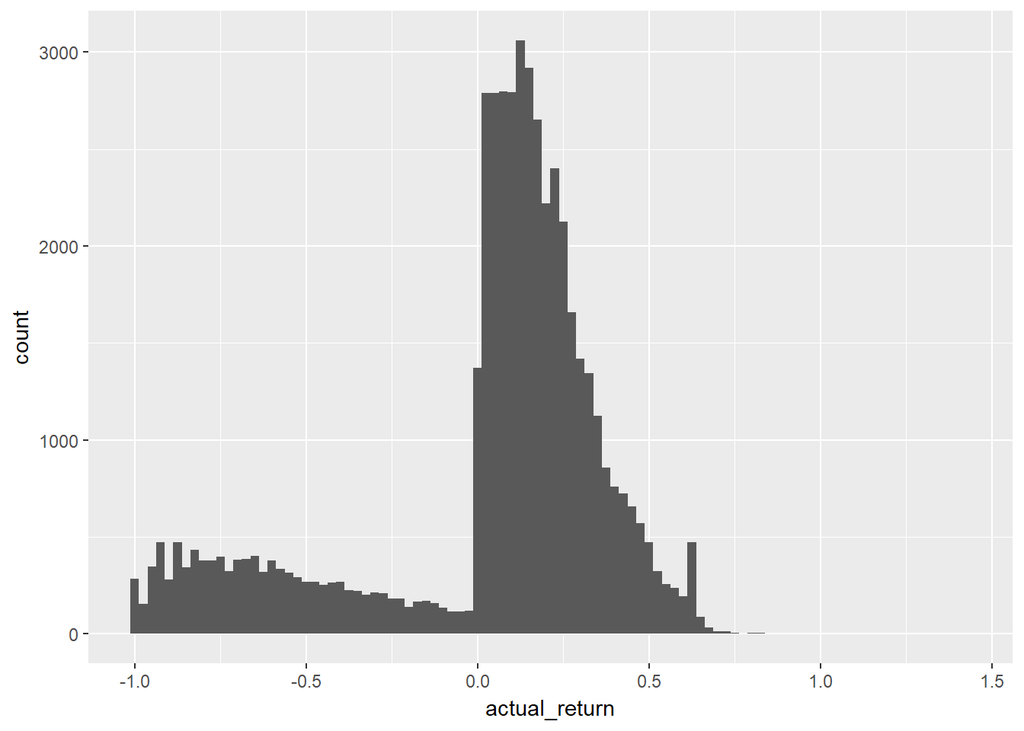

Most loans are profitable for the bank, with more common profits ranging from just breaking even (.0) to 50 percent (.5). There is a strange peak above 0.5, and I’m not sure why that is. If I were working for Prosper, I would definitely look at that. But for the sake of this project, I’m going to move past it.

The formula I used for acual return was bank_profit_current divided by loan_amount.

Question:

- Is Prosper’s model for predicting profit conservative? Or pretty accurate?
- What is the distribution of debt-to-income ratio for borrowers?

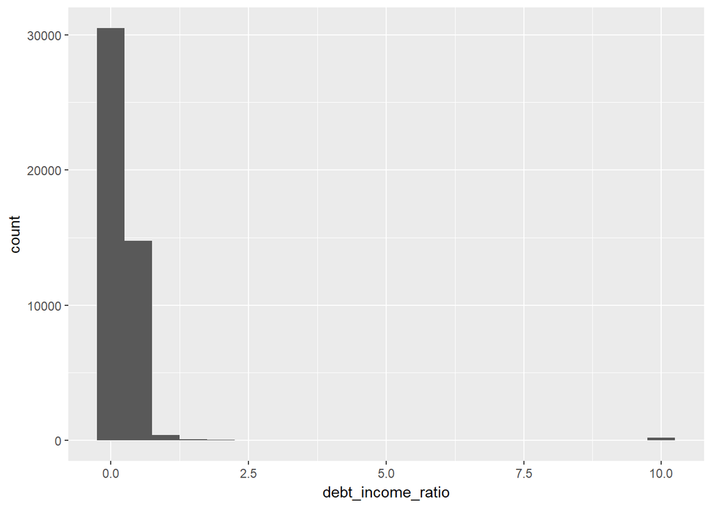

And zoomed in to remove that outlier column:

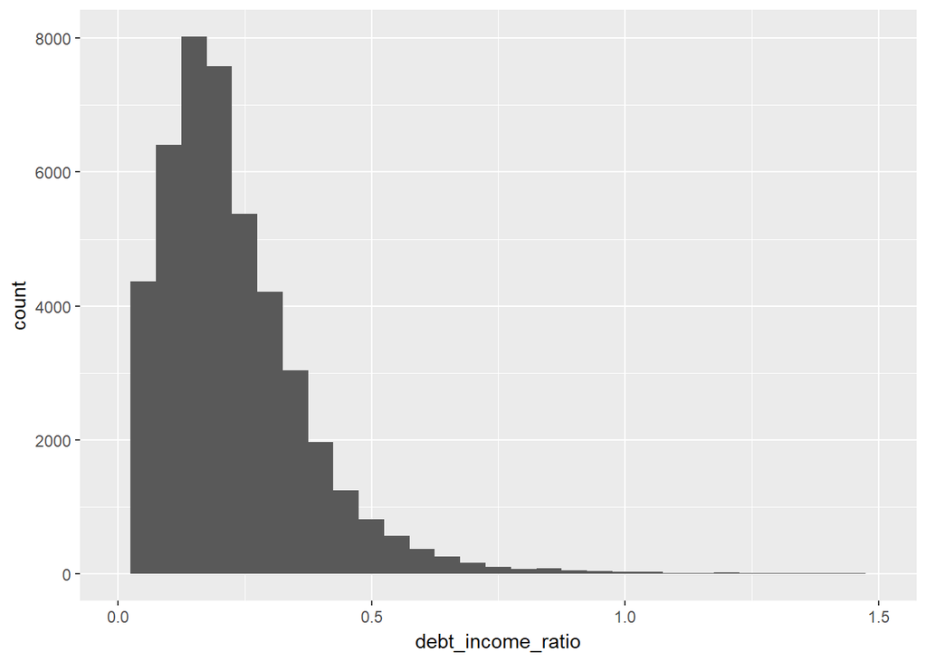

The graph peaks at the 0.125-0.175 bin (or 12.5 to 17.5 percent debt-to-income ratio).

# Univariate Analysis

### What is the structure of your dataset?

I decided to focus my investigation on loans that have been completed or charged off. There are 50,066 observations that meet this criteria.

- In the closed_loans dataset, there are 38,074 completed loans and 11,992 charged off loans. 24.0 percent of closed Prosper loans were charged off.
- Prosper loans are one, three, or five years in duration.
- The most common credit score for borrowers is between 665 and 725.
- The average profit per loan is $21.12.
- The loan amount for at least half of Prosper loans in the closed_loan dataset is equal to or less than $5,000.

### What is/are the main feature(s) of interest in your dataset?

For the rest of this analysis, I would like to focus on what variables can help predict actual_return.

I anticipate that the following variables will have the strongest correlation to actual_return:

- credit_score_average
- loan_term_years
- loan_amount

### What other features in the dataset do you think will help support your investigation into your feature(s) of interest?

I will also explore what covariation exists between actual_return and the following variables. I expect less of a correlation amongst these, but want to check to see if any of these have a higher impact than I would expect:

- employment_status
- debt_income_ratio
- employment_duration_years
- stated_annual_income

### Did you create any new variables from existing variables in the dataset?

Yes. I transformed several variables into forms that I feel will be more concise for visualization purposes:

- credit_score_average: calculated from credit_score_lower and credit_score_upper
- loan_term_years: loan_term_months divided by 12; also converted to a factor
- employment_duration_years: employment_duration_months divided by 12
- stated_annual_income: stated_income_monthly multiplied by 12

I wanted one variable to use for credit score, rather than two. And I find it easier to interpret the data when the loan term, employment duration, and income is stated annually rather than monthly.

Now, I have the following variables to move into the bivariate analysis:

```
## [1] 50066    13
```

```
##  [1] "loan_status_current"       "loan_term_years"
##  [3] "estimated_return"          "loan_amount"
##  [5] "principal_paid"            "interest_and_fees_paid"
##  [7] "bank_profit_current"       "actual_return"
##  [9] "employment_status"         "employment_duration_years"
## [11] "stated_annual_income"      "credit_score_average"
## [13] "debt_income_ratio"
```

### Of the features you investigated, were there any unusual distributions? Did you perform any operations on the data to tidy, adjust, or change the form of the data? If so, why did you do this?

See above section for changes made to the dataset.

# Bivariate Plots Section

Let’s start by looking at the correlations between different variables.

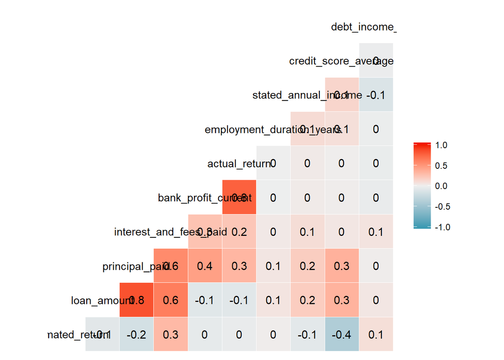

Question:

- How is actual_return related to credit_score_average?

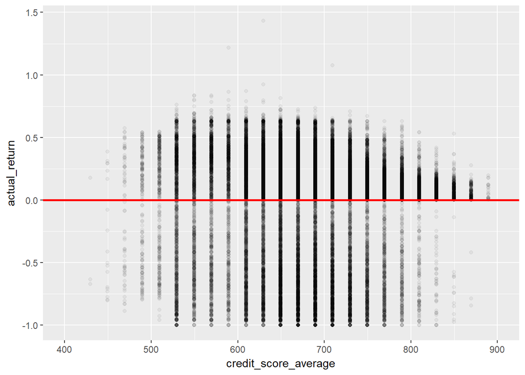

It doesn’t look like I will be able to use credit score in a predictive model for actual return. I really expected more of a correlation. It does look like individuals who have a score over 800 are a very safe bet for investment. Perhaps the overplotting on this graph is hiding a trend that is there.

Question:

- Would a grouped boxplot show a better trend?

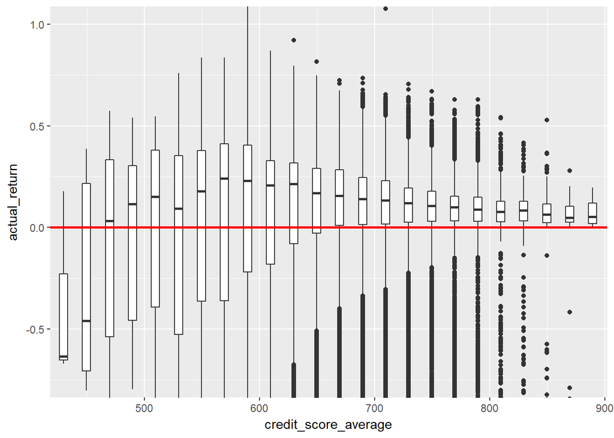

It looks like the median return is above 0 for all ranges except those centering at 450 and below. And the peak in the median return occurs at a credit score of 570.

With this graph, it looks like there is a pattern in the relationship between credit score and return. Those with poor or fair credit scores are bringing the highest rate of return. This is likely because these individuals pay higher interest rates.

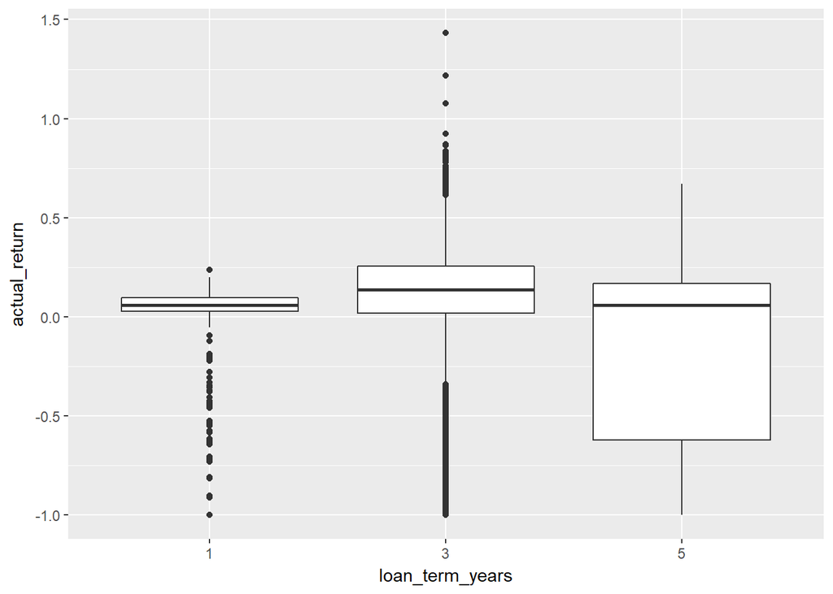

It looks like three-year loans have the highest median percentage of return. And it looks like Prosper is losing the most money on five-year loans. In fact, almost half of five-year loans are losing money.

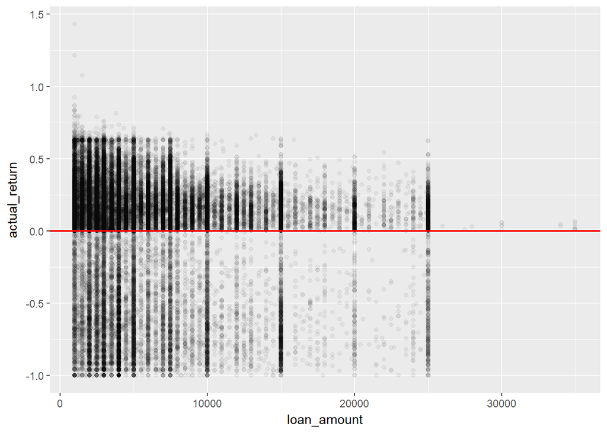

Here we see the effects of overplotting within the bands of most common loan amounts. It does look like the return falls much more above 0, which is good for Prosper. Let’s take a look at this with a boxplot grouping to see where the medians lie by $1,000 bins.

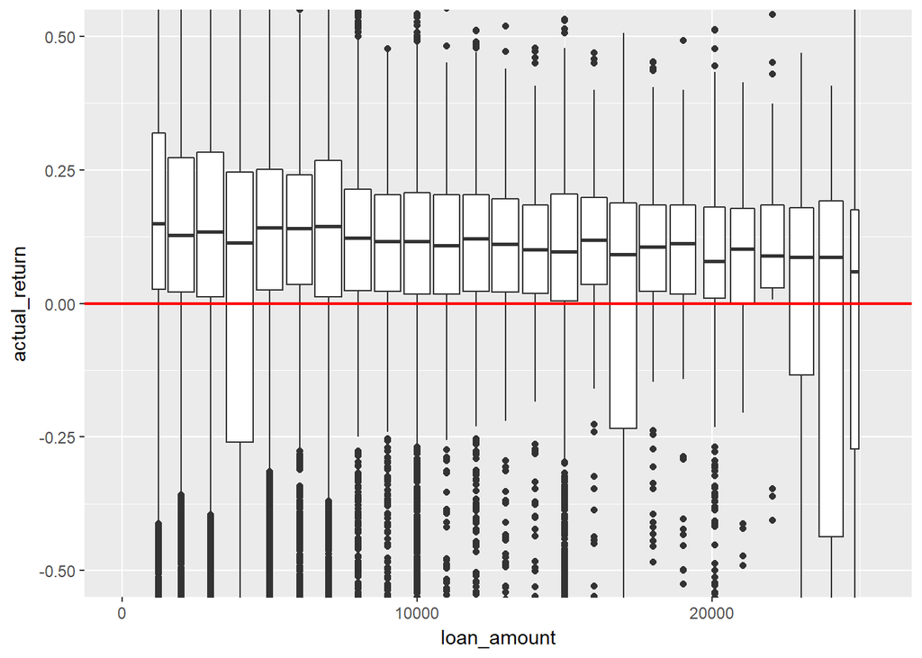

Return is above 0 for all loan amounts. There really is no evidence of variation in the loan amount changing the ROI.

Question:

- How does debt-to-income-ratio impact return?

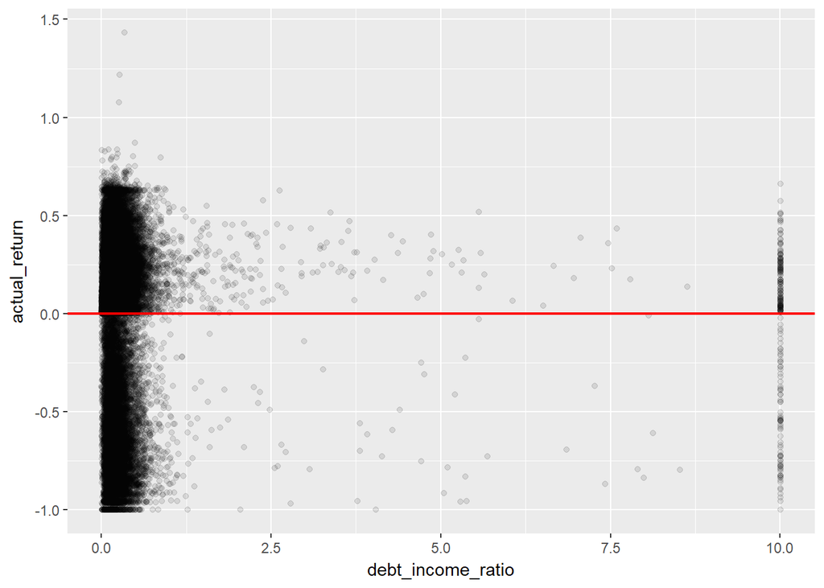

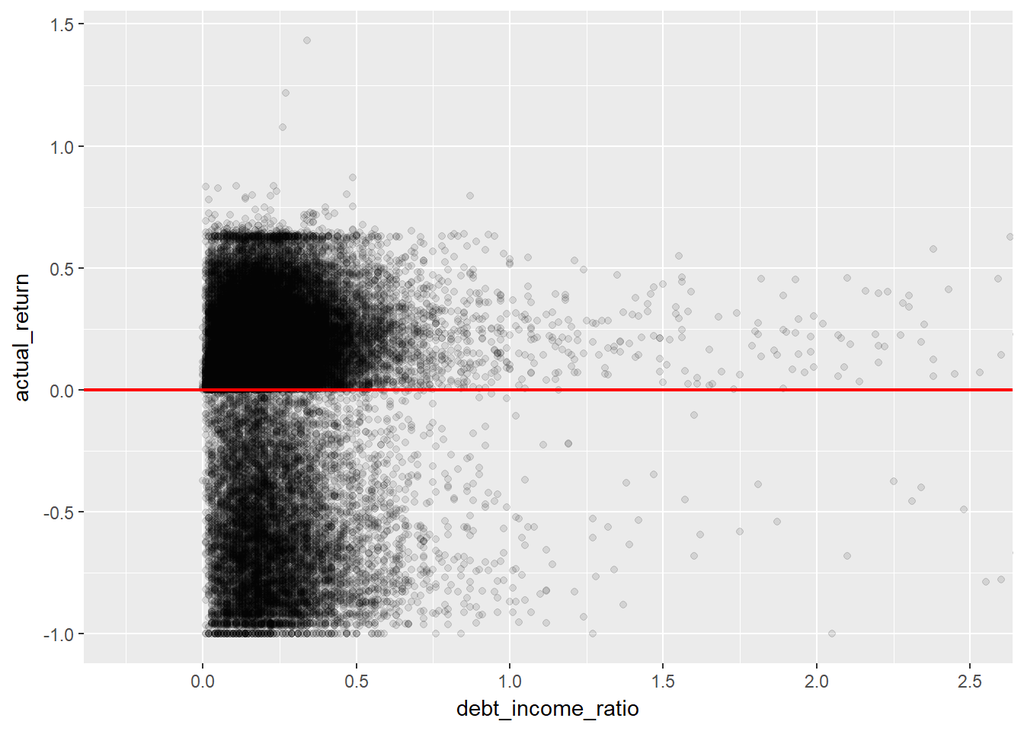

Question:

- How does employment status impact return?

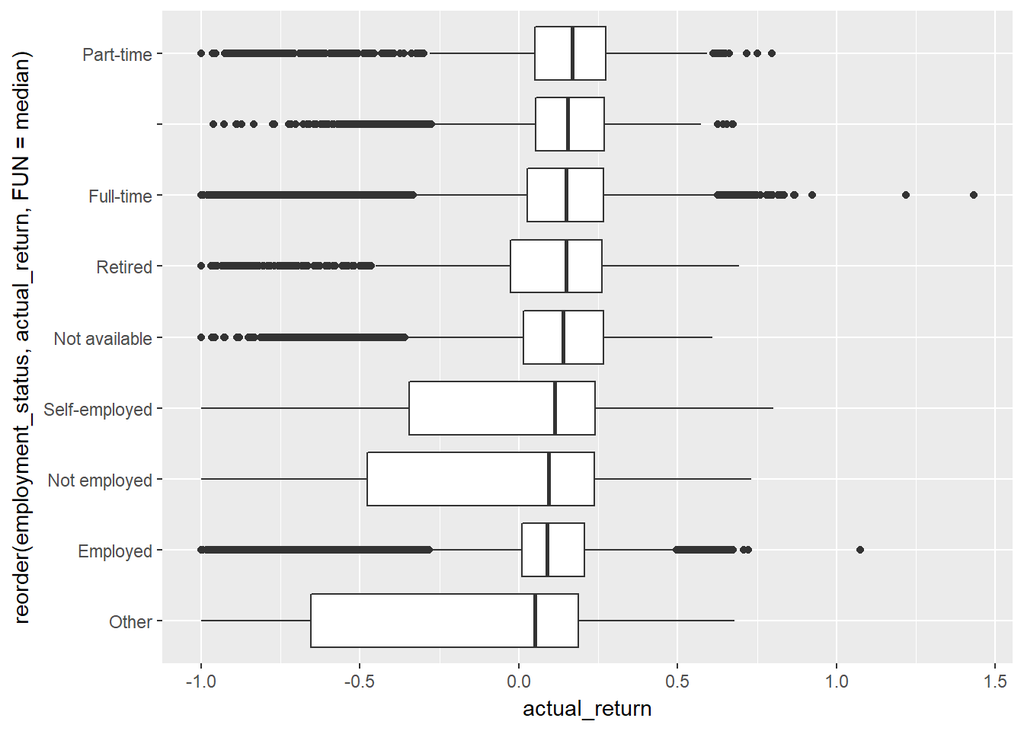

These are some strange tiers, with redundancy. My guess is that the option set changed at some point in data collection. For example “employed” was later changed to two options – “part-time” and “full-time.”

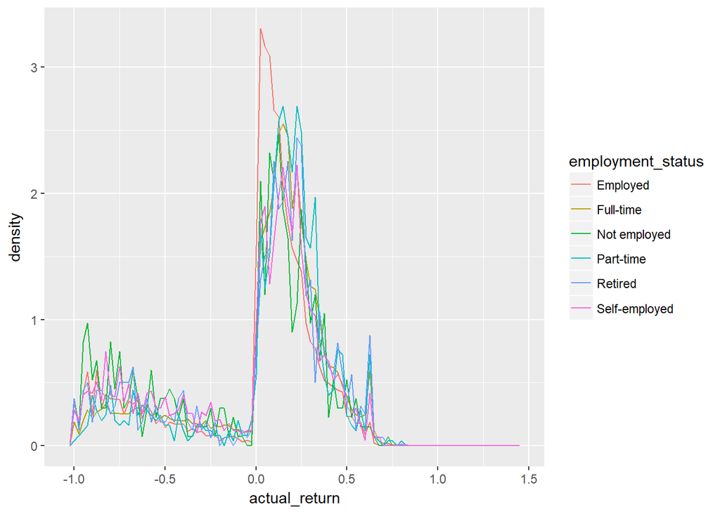

The plot shows density, so that the count of each category doesn’t scew the graph. The graph shows a proportion for each category.

It is surprising to me that those with an employment_status of ‘employed’ bring Prosper a lower actual_return. However, I know that some of the data collection criteria changed in 2009, based on the data dictionary. I don’t know exactly when the employment_status optionset would have changed. But if ‘Employed’ is from an earlier date, it’s not a good comparison (because there are many environmental differences that could make a difference if the data was collected during two different time periods).

Let’s zoom in to the peak area of this graph.

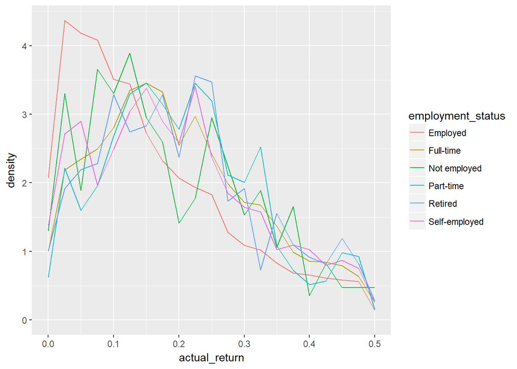

It’s interesting that retired and part-time individuals seem to peak at a higher actual_return rate. Perhaps it is a similar phenomenon to why Prosper makes a better return for those with lower credit scores – perhaps these individuals are assigned a higher interest rate.